# HW03

## Instruction

Using the NCBI API, look for papers that show up under the term “sars-cov-2 trial vaccine.” Look for the data in the pubmed database, and then retrieve the details of the paper as shown in lab 7. How many papers were you able to find?

```r
library(stringr)
library(xml2)
library(httr)

website <- xml2::read_html("https://pubmed.ncbi.nlm.nih.gov/?term=sars-cov-2+trial+vaccine")

counts <- xml2::xml_find_first(website, "/html/body/main/div[9]/div[2]/div[2]")
counts <- as.character(counts)
stringr::str_extract(counts, "[0-9,]+")
```

```
## [1] "563"
```

Using the list of pubmed ids you retrieved, download each papers’ details using the query parameter rettype = abstract. If you get more than 250 ids, just keep the first 250.

```r
query_ids <- GET(
  url = "https://eutils.ncbi.nlm.nih.gov/entrez/eutils/esearch.fcgi",
  query = list(
    db  = "pubmed",
    term = "sars-cov-2 trial vaccine",
    retmax = 1000
   )
)

# Extracting the content of the response of GET
ids <- content(query_ids)

# Turn the result into a character vector
ids <- as.character(ids)

# Find all the ids  "[[1]]" :return string vector
ids <- str_extract_all(ids, "<Id>[0-9]+</Id>")[[1]]

# Remove all the leading and trailing <Id> </Id>. Make use of "|"
ids <- str_remove_all(ids, "<Id>|</Id>")
```

As we did in lab 7. Create a dataset containing the following:

Pubmed ID number, Title of the paper, Name of the journal where it was published, Publication date, and Abstract of the paper (if any).

```r
publications <- GET(
  url   = "https://eutils.ncbi.nlm.nih.gov/entrez/eutils/efetch.fcgi",
  query = list (
    db      = "pubmed",
    id      = paste(ids, collapse = ","),
    retmax  = 1000,
    rettype = "abstract"
  )
)

# Turning the output into character vector
publications <- content(publications)
publications_txt <- as.character(publications)

pub_char_list <- xml_children(publications)
pub_char_list <- sapply(pub_char_list, as.character)


#retrieve abstract
abstracts <- str_extract(pub_char_list, "<Abstract>(\\n|.)+</Abstract>")
#remove html text
abstracts <- str_remove_all(abstracts, "</?[[:alnum:]]+>")
#remove new line and spaces
abstracts <- str_replace_all(abstracts, "\\s+"," ")


#retrieve journal name
journal <- str_extract(pub_char_list, "<Title>(\\n|.)+</Title>")
journal <- str_remove_all(journal, "</?[[:alnum:]]+>")
journal <- str_replace_all(journal, "\\s+"," ")

#retrieve pubdate
pubdate <- str_extract(pub_char_list, "<PubDate>(\\n|.)+</PubDate>")
pubdate <- str_remove_all(pubdate, "</?[[:alnum:]]+>")
pubdate <- str_replace_all(pubdate,"\\s+"," ")

#retrieve titles
titles <- str_extract(pub_char_list, "<ArticleTitle>(\\n|.)+</ArticleTitle>")
titles <- str_remove_all(titles, "</?[[:alnum:]]+>")
titles <- str_replace_all(titles, "\\s+"," ")

database <- data.frame(
  PubMedID  = ids,
  Journal   = journal,
  PubDate   = pubdate,
  Title     = titles,
  Abstract  = abstracts
)

library(kableExtra)
kable(database)
```

| PubMedID | Journal | PubDate | Title | Abstract |
| --- | --- | --- | --- | --- |
| 33043110 | Informatics in medicine unlocked | 2020 Oct 04 | EXPLORING SURFACE GLYCOPROTEIN TO DESIGN MULTI-EPITOPE VACCINE AGAINST COVID-19. | Stimulation and generation of T and B cell mediated long-term immune response is essential for the curbing of a deadly virus such as SAR-CoV-2. Immunoinformatics approach in vaccine design takes advan… |
| 33042591 | Nepal journal of epidemiology | 2020 Sep | Impact of COVID-19 on clinical trials and clinical research: A systematic review. | Background: The World Health Organization has reported more than 31,186,000 confirmed cases of coronavirus disease-19 (COVID-19), including 962,343 deaths, worldwide as on September 21, 2020. The curr… |
| 33038433 | Journal of hepatology | 2020 Oct 07 | COVID-19: discovery, diagnostics and drug development. | An epidemic of acute respiratory syndrome (Covid-19) started in humans in Wuhan in 2019, and became a pandemic. Groups from China Identified and sequenced the virus responsible for COVID-19, named SAR… |
| 33022293 | Medecine et maladies infectieuses | 2020 Oct 03 | Clinical trial protocols of repurposed prophylaxis for COVID-19: a review. | Efficient therapeutic strategies are needed to counter the COVID-19 pandemic, caused by the SARS-CoV-2 virus. In a context where specific vaccines are not yet available, the containment of the pandemi… |
| 33013255 | International journal of peptide research and therapeutics | 2020 Sep 28 | Screening of FDA Approved Drugs Against SARS-CoV-2 Main Protease: Coronavirus Disease. | At the end of December 2019, a new strain of coronavirus was identified in the Wuhan city of Hubei province in China. Within a shorter period of time, an unprecedented outbreak of this strain was witn… |
| 33012348 | Mayo Clinic proceedings | 2020 10 | SARS-CoV-2 Vaccine Development: Current Status. | In the midst of the severe acute respiratory syndrome coronavirus 2 pandemic and its attendant morbidity and mortality, safe and efficacious vaccines are needed that induce protective and long-lived i… |
| 32998488 | Tidsskrift for den Norske laegeforening : tidsskrift for praktisk medicin, ny raekke | 2020 09 29 | Status of COVID-19 vaccine development. | NA |
| 32998157 | Nature | 2020 Sep 30 | COVID-19 vaccine BNT162b1 elicits human antibody and TH1 T-cell responses. | An effective vaccine is needed to halt the spread of the severe acute respiratory syndrome coronavirus-2 (SARS-CoV-2) pandemic. Recently, we reported safety, tolerability and antibody response data fr… |
| 32997699 | PloS one | 2020 | Analysis of COVID-19 clinical trials: A data-driven, ontology-based, and natural language processing approach. | With the novel COVID-19 pandemic disrupting and threatening the lives of millions, researchers and clinicians have been recently conducting clinical trials at an unprecedented rate to learn more about… |
| 32994572 | Nature | 2020 10 | COVID vaccine confidence requires radical transparency. | NA |
| 32991794 | The New England journal of medicine | 2020 Sep 29 | Safety and Immunogenicity of SARS-CoV-2 mRNA-1273 Vaccine in Older Adults. | <AbstractText Label=“BACKGROUND” NlmCategory=“BACKGROUND”>Testing of vaccine candidates to prevent infection with severe acute respiratory syndrome coronavirus 2 (SARS-CoV-2) in an older population is… |
| 32988688 | Vaccine | 2020 10 21 | Intention to participate in a COVID-19 vaccine clinical trial and to get vaccinated against COVID-19 in France during the pandemic. | <AbstractText Label=“INTRODUCTION”>The world is facing the COVID-19 pandemic. The development of a vaccine is challenging. We aimed to determine the proportion of people who intend to get vaccinated a… |
| 32985963 | Viral immunology | 2020 Sep 23 | Coronavirus Disease 2019 Vaccine Development: An Overview. | To this day, the coronavirus disease 2019 (COVID-19) pandemic has not shown signs of abating. Moreover, the virus responsible for the pandemic, severe acute respiratory syndrome coronavirus 2, has evo… |
| 32978611 | Nature | 2020 10 | COVID-vaccine results are on the way - and scientists’ concerns are growing. | NA |
| 32974268 | Frontiers in public health | 2020 | Overview of the First 6 Months of Clinical Trials for COVID-19 Pharmacotherapy: The Most Studied Drugs. | SARS-CoV-2 rapidly spread from China until it was defined a pandemic by WHO in March 2020. Related scientific papers have rapidly extended information regarding the diagnosis, treatment and epidemiolo… |
| 32973779 | Frontiers in immunology | 2020 | The 2020 Pandemic: Current SARS-CoV-2 Vaccine Development. | Coronaviruses are enveloped viruses with a positive-sense single-stranded RNA genome infecting animals and humans. Coronaviruses have been described more than 70 years ago and contain many species. Se… |
| 32969973 | Current opinion in HIV and AIDS | 2020 11 | Coronavirus disease-19 vaccine development utilizing promising technology. | <AbstractText Label=“PURPOSE OF REVIEW”>Coronavirus disease-19 (COVID-19) is a highly transmittable and pathogenic pneumonia-causing disease, which is caused by severe acute respiratory syndrome coron… |
| 32969369 | Journal of Nepal Health Research Council | 2020 Sep 07 | Safety and Efficacy of Different Therapeutic Interventions on Prevention and Treatment of COVID-19. | Severe acute respiratory syndrome coronavirus 2 (SARS-CoV-2) is the strain of coronavirus that causes coronavirus disease 2019 (COVID-19), a respiratory illness. COVID-19 has now become a global publi… |
| 32967006 | Nature | 2020 Sep 23 | SARS-CoV-2 vaccines in development. | Severe acute respiratory syndrome coronavirus 2 (SARS-CoV-2) was first reported in late 2019 in China and is the causative agent of the coronavirus disease 2019 (COVID-19) pandemic. To mitigate the ef… |
| 32963672 | The Pan African medical journal | 2020 | Expedited COVID-19 vaccine trials: a rat-race with challenges and ethical issues. | The intense global efforts are directed towards development of vaccines to halt the COVID-19 virus pandemic. There are 160 candidate vaccines under clinical trials across the world using different mol… |
| 32958009 | Journal of translational medicine | 2020 09 21 | The use of mesenchymal stromal cells in the treatment of coronavirus disease 2019. | More than seven months into the coronavirus disease -19 (COVID-19) pandemic, infection from the severe acute respiratory syndrome coronavirus-2 (SARS-CoV-2) has led to over 21.2 million cases and resu… |
| 32943115 | Trials | 2020 Sep 17 | Using BCG vaccine to enhance non-specific protection of health care workers during the COVID-19 pandemic: A structured summary of a study protocol for a randomised controlled trial in Denmark. | <AbstractText Label=“OBJECTIVES” NlmCategory=“OBJECTIVE”>The Bacille Calmette-Guérin (BCG) vaccine against tuberculosis is associated with non- specific protective effects against other infections, an… |
| 32934758 | Canadian respiratory journal | 2020 | Tuberculosis and COVID-19: Lessons from the Past Viral Outbreaks and Possible Future Outcomes. | <AbstractText Label=“Background”>The threat of contagious infectious diseases is constantly evolving as demographic explosion, travel globalization, and changes in human lifestyle increase the risk of… |
| 32934375 | Nature | 2020 09 | Researchers highlight ‘questionable’ data in Russian coronavirus vaccine trial results. | NA |
| 32933536 | Journal of translational medicine | 2020 09 15 | Pathophysiology and treatment strategies for COVID-19. | The outbreak of Coronavirus disease of 2019 (COVID-19) caused by the Severe Acute Respiratory Syndrome coronavirus 2 (SARS-CoV-2), has posed a serious health threat. The increasing number of COVID-19 … |
| 32929259 | Nature | 2020 09 | Scientists relieved as coronavirus vaccine trial restarts - but question lack of transparency. | NA |
| 32918548 | Journal of the Pediatric Infectious Diseases Society | 2020 Sep 12 | Multicenter interim guidance on use of antivirals for children with COVID-19/SARS-CoV-2. | <AbstractText Label=“BACKGROUND” NlmCategory=“BACKGROUND”>Although Coronavirus Disease 2019 (COVID-19) is a mild infection in most children, a small proportion develop severe or critical illness. Data… |
| 32918053 | Nature | 2020 09 | China’s coronavirus vaccine shows military’s growing role in medical research. | NA |
| 32908297 | Nature | 2020 09 | The underdog coronavirus vaccines that the world will need if front runners stumble. | NA |
| 32908295 | Nature | 2020 Sep 09 | A leading coronavirus vaccine trial is on hold: scientists react. | NA |

[output cut: 197 more lines]

A new dataset has been added to the data science data repository https://github.com/USCbiostats/data-science-data/tree/master/03_pubmed. The dataset contains 3241 abstracts from articles across 5 search terms. Your job is to analyse these abstracts to find interesting insights.

Tokenize the abstracts and count the number of each token. Do you see anything interesting? Does removing stop words change what tokens appear as the most frequent? What are the 5 most common tokens for each search term after removing stopwords? Tokenize the abstracts into bigrams. Find the 10 most common bigram and visualize them with ggplot2.

We can see there are 5 search term in the dataset, which are “covid”, “prostate cancer”, “preeclampsia”, “cystic fibrosis” and “meningitis”.

```r
library(tidyverse)
```

```r
library(dplyr)
library(forcats)
library(ggplot2)
library(tidytext)

pubmed <- read_csv("/Users/sherryshen/Desktop/pubmed.txt")
pubmed <- pubmed %>%
  select(abstract,term)

pubmed %>%
  count(term, sort =TRUE)
```

```
## # A tibble: 5 x 2
##   term                n
##   <chr>           <int>
## 1 covid             981
## 2 prostate cancer   787
## 3 preeclampsia      780
## 4 cystic fibrosis   376
## 5 meningitis        317
```

```r
pubmed %>%
  filter(term %in% "covid") %>%
  unnest_tokens(word, abstract) %>%
  count(word, sort = TRUE) %>%
  top_n(5, n)
```

```
## # A tibble: 5 x 2
##   word      n
##   <chr> <int>
## 1 the    9741
## 2 of     7668
## 3 covid  7275
## 4 19     7035
## 5 and    6861
```

```r
#remove stopwords
library(stringr)
pubmed %>%
  filter(term %in% "covid") %>%
  unnest_tokens(word, abstract) %>%
  anti_join(stop_words)%>%
  count(word, sort = TRUE) %>%
  top_n(5, n)
```

```
## # A tibble: 5 x 2
##   word         n
##   <chr>    <int>
## 1 covid     7275
## 2 19        7035
## 3 patients  2293
## 4 disease    943
## 5 pandemic   800
```

If we token abstract in to bi-grams, we have the following results:

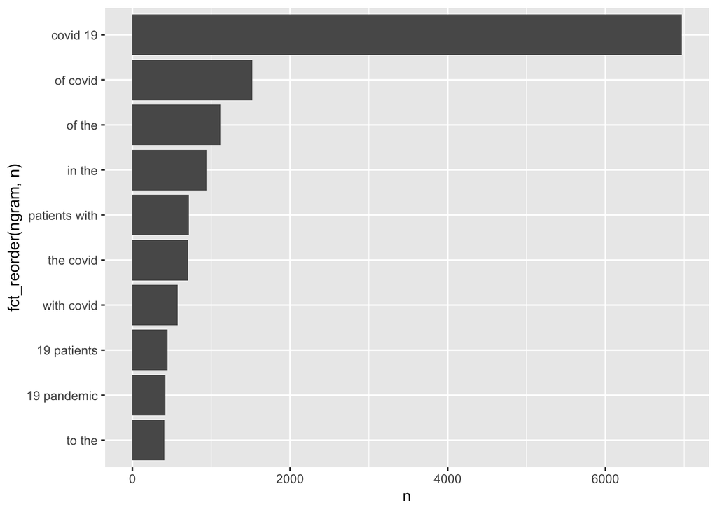

```r
#token bi-gram
pubmed %>%
  filter(term %in% "covid") %>%
  unnest_ngrams(ngram, abstract, n = 2) %>%
  count(ngram, sort = TRUE) %>%
  top_n(10, n) %>%
  ggplot(aes(x = n, y = fct_reorder(ngram, n)))+
  geom_col()
```

For term “prostate cancer”, we can see the most 5 common words before removing stop_words are: “the, of, and prostate, cancer”; After removing stop words, we have “prostate, cancer, patients, treatment, disease”.

```r
pubmed %>%
  filter(term %in% "prostate cancer") %>%
  unnest_tokens(word, abstract) %>%
  count(word, sort = TRUE) %>%
  top_n(5, n)
```

```
## # A tibble: 5 x 2
##   word         n
##   <chr>    <int>
## 1 the       6100
## 2 of        5682
## 3 and       4417
## 4 cancer    3840
## 5 prostate  3832
```

```r
pubmed %>%
  filter(term %in% "prostate cancer") %>%
  unnest_tokens(word, abstract) %>%
  anti_join(stop_words)%>%
  count(word, sort = TRUE) %>%
  top_n(5, n)
```

```
## # A tibble: 5 x 2
##   word          n
##   <chr>     <int>
## 1 cancer     3840
## 2 prostate   3832
## 3 patients    934
## 4 treatment   926
## 5 disease     652
```

If we token abstract in to bi-grams, we have the following results:

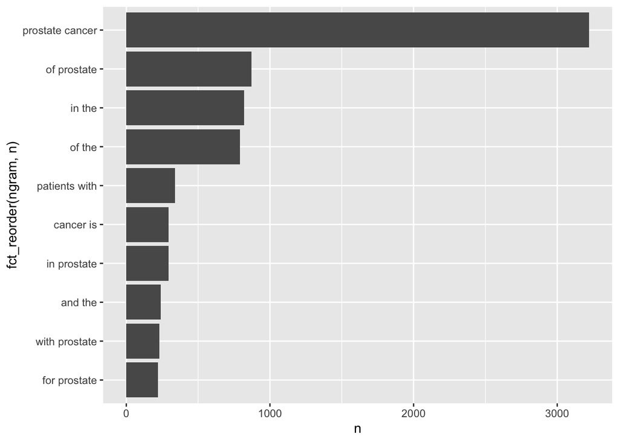

```r
#token bi-gram
pubmed %>%
  filter(term %in% "prostate cancer") %>%
  unnest_ngrams(ngram, abstract, n = 2) %>%
  count(ngram, sort = TRUE) %>%
  top_n(10, n) %>%
  ggplot(aes(x = n, y = fct_reorder(ngram, n)))+
  geom_col()
```

For term “preeclampsia”, we can see the most 5 common words before removing stop_words are: “the, of, and, in, to”; After removing stop words, we have “pre, eclampsia, preeclampsia, women, pregnancy”.

```r
pubmed %>%
  filter(term %in% "preeclampsia") %>%
  unnest_tokens(word, abstract) %>%
  count(word, sort = TRUE) %>%
  top_n(5, n)
```

```
## # A tibble: 5 x 2
##   word      n
##   <chr> <int>
## 1 the    7119
## 2 of     6837
## 3 and    5255
## 4 in     3869
## 5 to     2651
```

```r
pubmed %>%
  filter(term %in% "preeclampsia") %>%
  unnest_tokens(word, abstract) %>%
  anti_join(stop_words)%>%
  count(word, sort = TRUE) %>%
  top_n(5, n)
```

```
## # A tibble: 5 x 2
##   word             n
##   <chr>        <int>
## 1 pre           2038
## 2 eclampsia     2005
## 3 preeclampsia  1863
## 4 women         1196
## 5 pregnancy      969
```

If we token abstract in to bi-grams, we have the following results:

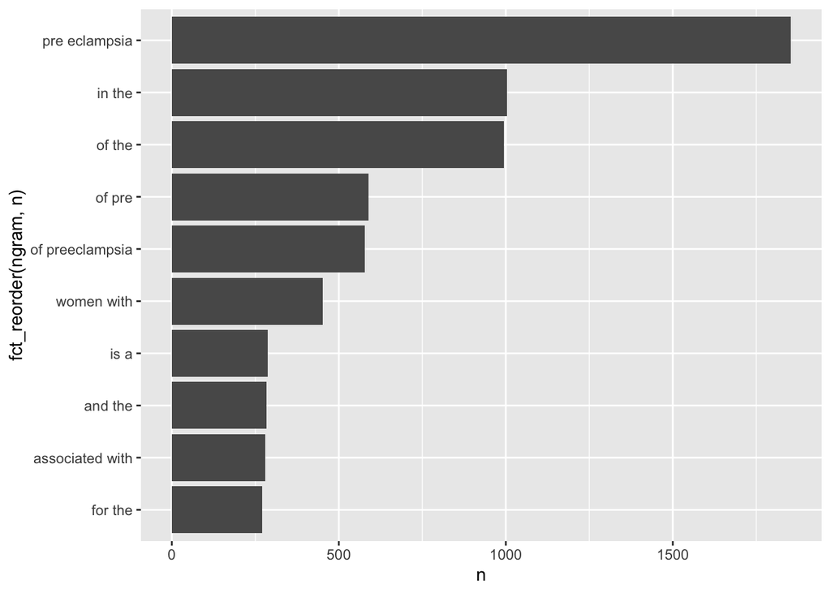

```r
#token bi-gram
pubmed %>%
  filter(term %in% "preeclampsia") %>%
  unnest_ngrams(ngram, abstract, n = 2) %>%
  count(ngram, sort = TRUE) %>%
  top_n(10, n) %>%
  ggplot(aes(x = n, y = fct_reorder(ngram, n)))+
  geom_col()
```

```r
pubmed %>%
  filter(term %in% "cystic fibrosis") %>%
  unnest_tokens(word, abstract) %>%
  count(word, sort = TRUE) %>%
  top_n(5, n)
```

```
## # A tibble: 5 x 2
##   word      n
##   <chr> <int>
## 1 the    2677
## 2 of     2304
## 3 and    1777
## 4 in     1497
## 5 to     1011
```

```r
pubmed %>%
  filter(term %in% "cystic fibrosis") %>%
  unnest_tokens(word, abstract) %>%
  anti_join(stop_words)%>%
  count(word, sort = TRUE) %>%
  top_n(5, n)
```

```
## # A tibble: 5 x 2
##   word         n
##   <chr>    <int>
## 1 fibrosis   867
## 2 cystic     862
## 3 cf         625
## 4 patients   586
## 5 disease    400
```

If we token abstract in to bi-grams, we have the following results:

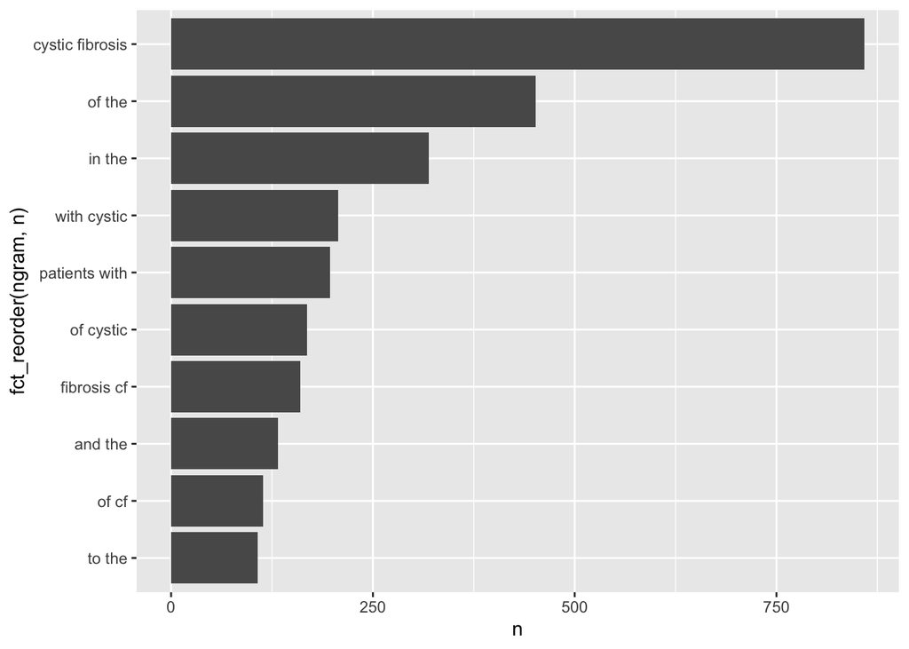

```r
#token bi-gram
pubmed %>%
  filter(term %in% "cystic fibrosis") %>%
  unnest_ngrams(ngram, abstract, n = 2) %>%
  count(ngram, sort = TRUE) %>%
  top_n(10, n) %>%
  ggplot(aes(x = n, y = fct_reorder(ngram, n)))+
  geom_col()
```

For term “meningitis”, we can see the most 5 common words before removing stop_words are: “the, of, and, in, a”; After removing stop words, we have “patients, meningitis, meningeal, csf, clinical”.

```r
pubmed %>%
  filter(term %in% "meningitis") %>%
  unnest_tokens(word, abstract) %>%
  count(word, sort = TRUE) %>%
  top_n(5, n)
```

```
## # A tibble: 5 x 2
##   word      n
##   <chr> <int>
## 1 the    2489
## 2 of     2269
## 3 and    1683
## 4 in     1322
## 5 a       830
```

```r
pubmed %>%
  filter(term %in% "meningitis") %>%
  unnest_tokens(word, abstract) %>%
  anti_join(stop_words)%>%
  count(word, sort = TRUE) %>%
  top_n(5, n)
```

```
## # A tibble: 5 x 2
##   word           n
##   <chr>      <int>
## 1 patients     446
## 2 meningitis   429
## 3 meningeal    219
## 4 csf          206
## 5 clinical     187
```

If we token abstract in to bi-grams, we have the following results:

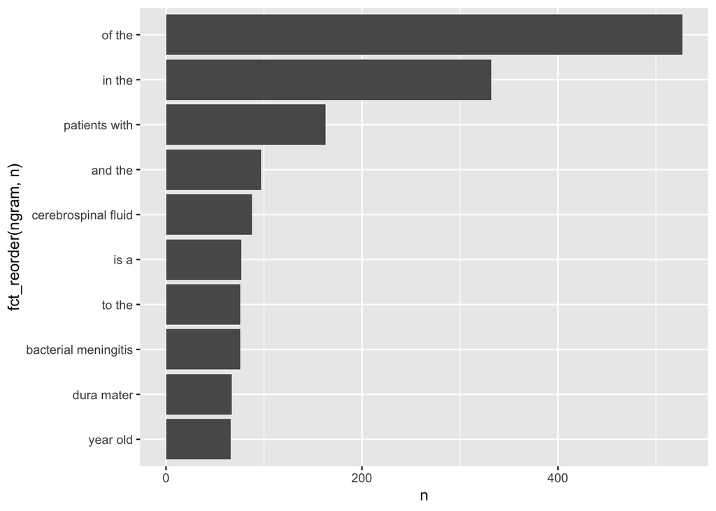

```r
#token bi-gram
pubmed %>%
  filter(term %in% "meningitis") %>%
  unnest_ngrams(ngram, abstract, n = 2) %>%
  count(ngram, sort = TRUE) %>%
  top_n(10, n) %>%
  ggplot(aes(x = n, y = fct_reorder(ngram, n)))+
  geom_col()
```

In summary, we can see that before removing the stop words, the tokens shows nothing interesting. After we remove the stop words, the most 5 frequent tokens for each term show words like “patients” and “disease”.

Calculate the TF-IDF value for each word-search term combination. (here you want the search term to be the “document”) What are the 5 tokens from each search term with the highest TF-IDF value? How are the results different from the answers you got in question 1?

```r
pubmed %>%
  unnest_tokens(word, abstract) %>%
  count(word, term) %>%
  bind_tf_idf(word, term, n) %>%
  arrange(desc(tf_idf))
```

```
## # A tibble: 39,240 x 6
##    word         term                n      tf   idf  tf_idf
##    <chr>        <chr>           <int>   <dbl> <dbl>   <dbl>
##  1 covid        covid            7275 0.0371  1.61  0.0597
##  2 prostate     prostate cancer  3832 0.0312  1.61  0.0502
##  3 eclampsia    preeclampsia     2005 0.0143  1.61  0.0230
##  4 preeclampsia preeclampsia     1863 0.0133  1.61  0.0214
##  5 meningitis   meningitis        429 0.00919 1.61  0.0148
##  6 cf           cystic fibrosis   625 0.0127  0.916 0.0117
##  7 fibrosis     cystic fibrosis   867 0.0176  0.511 0.00901
##  8 cystic       cystic fibrosis   862 0.0175  0.511 0.00896
##  9 meningeal    meningitis        219 0.00469 1.61  0.00755
## 10 pandemic     covid             800 0.00408 1.61  0.00657
## # … with 39,230 more rows
```